# Доклад по дисциплине основы администрирования ОС

Планировщик заданий Windows

Павличенко Родион Андреевич

1132246838@pfur.ru

Российский университет дружбы народов

2025-05-10

# Информация

## Докладчик

- Павличенко Родион Андреевич
- Cтудент
- Группа НПИбд-02-24
- Российский университет дружбы народов им. П. Лумумбы
- 1132246838@pfur.ru

# Теоретическая часть

## Цель

Провести комплексный анализ Планировщика заданий Windows как ключевого системного компонента для автоматизации административных задач, с фокусом на его архитектуре, функциональных возможностях и управлении

## Задачи

1)Определить роль и назначение Планировщика заданий в ОС Windows.

2)Проследить эволюцию инструментов планирования от ранних версий ОС к современной реализации.

3)Детально проанализировать архитектурные компоненты Планировщика: задачи, триггеры, действия, условия и параметры.

4)Рассмотреть ключевые сценарии использования в контексте системного администрирования.

5. Исследовать механизмы обеспечения безопасности и методы диагностики функционирования Планировщика заданий.

## Назначение и место в архитектуре операционной системы

[figure not shown]

Планировщик заданий представляет собой службу (Service) ОС, которая обеспечивает выполнение действий в заданное время или при наступлении определенных событий

## Эволюция инструментов автоматизации в Windows

[figure not shown]

Исторически в Windows NT существовала консольная утилита at.exe, которая позволяла планировать запуск задач по времени

## Задачи, триггеры и действия

Основной единицей планирования является задача (Task). Это контейнер, который объединяет все параметры выполнения определенной операции

Действие (Action) определяет, какая операция будет выполнена.

Триггер (Trigger) — это условие, которое инициирует выполнение задачи.

## Для обеспечения гибкости и надежности помимо основных компонентов задача включает в себя два дополнительных раздела:

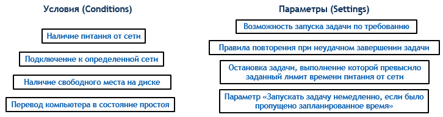

## Ключевые сценарии применения Планировщика заданий в профессиональной деятельности системного администратора

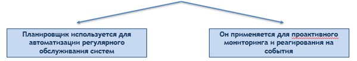

## Безопасность является неотъемлемой частью работы Планировщика заданий, поскольку задачи часто выполняются с повышенными привилегиями

[figure not shown]

Для мониторинга и диагностики неисправностей Планировщик заданий ведет детальные журналы. Вкладка «История» в свойствах конкретной задачи отображает все попытки ее выполнения с соответствующими кодами завершения

## Да что там Windows! Самая неотлаженная и глючная система это жизнь. ©Стас Янковский

[figure not shown]